# Analyse how much vCPU and RAM predict the instance limit

Raoni Smaneoto

### The data

The data consists on a csv used by fogbow to map the user requirements to an AWS instance. The cloud (aws) provide some instances_types that must be selected before launch it. The instances_types varies according to its attributes, like storage, vCPU, Memory, GPU etc.

```r
data = readr::read_csv(here::here("data/flavors.csv"))
data
```

| Instance Type | vCPU | Memory | Storage | Processor | Network Performance (Gbps) | Dedicated EBS Bandwidth (Mbps) | GPUs (GB) | Memory GPU (GB) | P2P Between GPUs | FPGAs | Limits |
| --- | --- | --- | --- | --- | --- | --- | --- | --- | --- | --- | --- |
| a1.medium | 1 | 2.000 | EBS-Only | AWS_Graviton_64bit | <10 | not-defined | No Support | No Support | No Support | No Support | 0 |
| a1.large | 2 | 4.000 | EBS-Only | AWS_Graviton_64bit | <10 | not-defined | No Support | No Support | No Support | No Support | 0 |
| a1.xlarge | 4 | 8.000 | EBS-Only | AWS_Graviton_64bit | <10 | not-defined | No Support | No Support | No Support | No Support | 0 |
| a1.2xlarge | 8 | 16.000 | EBS-Only | AWS_Graviton_64bit | <10 | not-defined | No Support | No Support | No Support | No Support | 0 |
| a1.4xlarge | 16 | 32.000 | EBS-Only | AWS_Graviton_64bit | <10 | not-defined | No Support | No Support | No Support | No Support | 0 |
| t1.micro | 1 | 0.613 | EBS-Only | Intel_Xeon | VeryLow | not-defined | No Support | No Support | No Support | No Support | 20 |
| t2.nano | 1 | 0.500 | EBS-Only | Intel_Xeon_3.3GHz | Low | not-defined | No Support | No Support | No Support | No Support | 20 |
| t2.micro | 1 | 1.000 | EBS-Only | Intel_Xeon_3.3GHz | LowToModerate | not-defined | No Support | No Support | No Support | No Support | 5 |
| t2.small | 1 | 2.000 | EBS-Only | Intel_Xeon_3.3GHz | LowToModerate | not-defined | No Support | No Support | No Support | No Support | 20 |
| t2.medium | 2 | 4.000 | EBS-Only | Intel_Xeon_3.3GHz | LowToModerate | not-defined | No Support | No Support | No Support | No Support | 20 |

[output cut: 184 more lines]

## Data overview

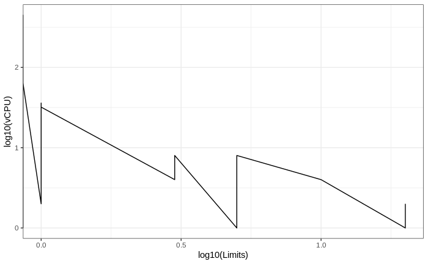

```r
data %>% ggplot(
  aes(x=log10(Limits), y=log10(vCPU))
) + geom_line()
```

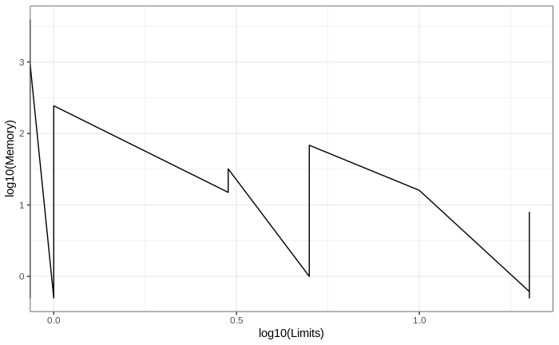

```r
data %>% ggplot(aes(x=log10(Limits), y=log10(Memory))) +
  geom_line()
```

## Model

```r
data_transformed = data %>% mutate(cpu_log=log10(vCPU), mem_log=log10(Memory), lim_log=log10(Limits)) %>%
  filter(lim_log > 0)
data_transformed %>%
  summarize(correlation_mem=cor(mem_log, lim_log, method="pearson"), correlation_cpu=cor(cpu_log, lim_log, method="pearson"))
```

| correlation_mem | correlation_cpu |
| --- | --- |
| -0.4703908 | -0.4490718 |

```r
model = lm(lim_log ~ cpu_log + mem_log, data=data_transformed)
tidy(model)
```

| term | estimate | std.error | statistic | p.value |
| --- | --- | --- | --- | --- |
| (Intercept) | 1.0046921 | 0.07887441 | 12.7378718 | 2.097360e-13 |
| cpu_log | -0.1538698 | 0.21735299 | -0.7079259 | 4.846426e-01 |
| mem_log | -0.1452595 | 0.13024985 | -1.1152372 | 2.739056e-01 |

```r
glance(model)
```

| r.squared | adj.r.squared | sigma | statistic | p.value | df | logLik | AIC | BIC | deviance | df.residual |
| --- | --- | --- | --- | --- | --- | --- | --- | --- | --- | --- |
| 0.2344964 | 0.1817031 | 0.2290603 | 4.441779 | 0.02076036 | 3 | 3.329642 | 1.340715 | 7.203659 | 1.521591 | 29 |

### Conclusion

I’ve found a expressive and negative correlation between the log10 of memory (GB) and the limits, and between log10 of cpu and limits. Besides, when I tried to find a linear model that shows how the limit changes in function of cpu_log and mem_log a expressive r_squared of 0.23 has been found. I think it was an expressive value, because there are so many other variables that have influence in the amount of instances from a determined instance_type that can be launched. That other variables haven’t been used for two reasons. The first and most important one: They don’t have a pattern that could be followed when using them in the model; the second one: I was curious about how much these two variables would influence the limit.